# Lab 13: Multilevel Generalized Linear Models

Isabel Laterzo, with text and code adopted/adapted from Simon Hoellerbauer and Rob Williams

April 21, 2019

## Mixed Effects Logistic Regression

As we learned earlier in the semester, generalized linear models use a link function $g(\cdot)$ that transforms the continuous, unbounded response variable $y$ of linear regression onto some discrete, bounded space. This allows us to model outcomes that are not continuous and do not have normally distributed errors. To obtain the relationship between the predictors and the untransformed response variable, we simply apply the inverse link function $g^{-1}(\cdot)$ to the right hand side of the model.

$$y = g^{-1}(\mathbf{X}\boldsymbol{\beta})$$

The linear combination of the explanatory variables is known as the *linear predictor*, usually termed $\eta$. Since software handles all the nuts and bolts of estimation via maximum likelihood, we can just throw some random effects terms into $\eta$ without having to worry. The only change we have to make in R is to use `glmer()` instead of `lmer()`. Let’s try this out with some survey data.

```r
library(plyr) # load plyr first to avoid dplyr conflicts later
library(MASS) # multivariate random normal distribution (load before tidyverse so that select isn't masked)
library(tidyverse)
library(haven)
library(labelled)
library(countrycode)

## read in data
ab <- read_sav('http://afrobarometer.org/sites/default/files/data/round-6/merged_r6_data_2016_36countries2.sav')
au <- read.csv('au.csv')
#scaling area to make it more tractable for lmer
au$AREA_scaled <- scale(au$AREA)

## drop missing observations, subset variables, and attach region
ab <- ab %>% filter(Q90A %in% 0:1, # close to party
                    EA_FAC_A %in% 0:1, # post office
                    EA_FAC_B %in% 0:1, # school
                    EA_FAC_C %in% 0:1, # police station
                    EA_FAC_D %in% 0:1, # clinic
                    Q4A %in% 0:5, # present economic condition
                    Q11A %in% 0:3, # property crime
                    Q11B %in% 0:3, # violent crime
                    Q52A %in% 0:3, # trust president
                    Q97 %in% 0:9) %>% # education level
  mutate(COUNTRY = to_factor(COUNTRY)) %>%
  dplyr::select(COUNTRY, Q90A, EA_FAC_A:EA_FAC_D, Q4A, Q11A, Q11B, Q52A, Q97) %>%
  left_join(au) %>%
  filter(!is.na(REGION))

## create custom coefficient map for texreg tables
tab_map <- list('EA_FAC_A' = 'Post Office', 'EA_FAC_B' = 'School',
                'EA_FAC_C' = 'Police Station', 'EA_FAC_D' = 'Clinic',
                'Q4A' = 'Economic Condition', 'Q11A' = 'Property Crime',
                'Q11B' = 'Violent Crime', 'Q52A' = 'Trust President',
                'Q97' = 'Education', '0|1' = '0|1', '1|2' = '1|2', '2|3' = '2|3')
```

Now that we’ve got our data, let’s fit a model. Write a model where whether a respondent feels close to a party is a function of their access to post offices, schools, police stations, and clinics, and their education level. Include a random intercept by country. In scalar form, this model looks like this:

$$\begin{align}
\text{party}_i &= \text{logit}^{-1}(\beta_0 + \beta_1post~office + \beta_2school + \beta_3police + \beta_4clinic + \beta_5education + \alpha_{country} + \epsilon) \\
\alpha &\sim \mathcal{N}(0, \sigma^2)
\end{align}$$

```r
library(lme4)
library(texreg)

## fit model with random intercepts
mod <- glmer(Q90A ~ EA_FAC_A + EA_FAC_B + EA_FAC_C + EA_FAC_D + Q97 +
               (1 | COUNTRY), data = ab, family = binomial(link = 'logit'))

## present results
htmlreg(mod, stars = .05, custom.coef.map = tab_map)
```

Statistical models

|  | Model 1 |
| --- | --- |
| Post Office | -0.13* |
|  | (0.03) |
| School | 0.11* |
|  | (0.04) |
| Police Station | -0.04 |
|  | (0.03) |
| Clinic | 0.03 |
|  | (0.03) |
| Education | -0.01* |
|  | (0.01) |
| AIC | 55186.64 |
| BIC | 55247.73 |
| Log Likelihood | -27586.32 |
| Num. obs. | 45581 |
| Num. groups: COUNTRY | 34 |
| Var: COUNTRY (Intercept) | 0.55 |

*p < 0.05

Interpretation of the fixed effects (in the `lmer()` sense!) is straightforward and equivalent to a regular logit. To understand the random effects, we need to do a little more work. The table tells us that the variance of the random intercept by country is 0.55. Since we have assumed mean 0 for the distribution of the random effects, a variance of 0.55 means that there isn’t large variation in the baseline probability of feeling close to a political party in the countries in our data.

## Quantities of Interest

### Quantities Over Range of A Variable

Since coefficients are no longer the marginal effect of $x$ on $y$ in GLMs, we often present quantities of interest to facilitate model interpretation. Unlike regular GLMs, we can no longer follow our standard approach and simply calculate $\text{logit}^{-1}(\mathbf{X}\boldsymbol{\beta})$ for a number of $\boldsymbol{\beta}$ vectors sampled from a multivariate normal distributions. Doing this only accounts for uncertainty in the **fixed effects** and ignores uncertainty in the **random effects** because it treats them as known and ignores the fact that they are estimates drawn from a distribution. If we do this, we’re in effect ignoring a large amount of the uncertainty in our model, and so the confidence intervals of our predictions will be smaller than they should be.

Luckily the `simulate.merMod()` function takes care of this for us. It is similar to the base `predict()`, except it allows you to draw new random effects from their distribution. This means we can use it to generate predicted probabilities be averaging across the predictions for all of our simulated coefficients. Below, we calculate the predicted probability of feeling close to a party as a function of education level. Because it becomes difficult to digest the results if we plot this for all countries (plus it will be very computationally expensive), we will choose three countries. Below, we plot the results for Malawi, Tanzania, and Zambia.

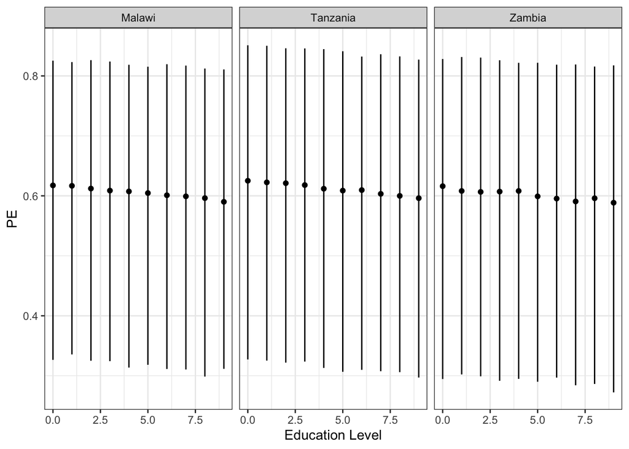

```r
library(doParallel) # parallel plyr
registerDoParallel(parallel::detectCores()) # use all cores

## subset to countries of interest
pred_dat <- ab %>% subset(COUNTRY %in% c('Malawi', 'Tanzania', 'Zambia'))

## repeat data for each value in Q97
pred_dat_full <- pred_dat[rep(seq_len(nrow(pred_dat)), length(unique(ab$Q97))), ]

## replace Q97 with simulated range of values
pred_dat_full$Q97 <- with(ab, rep(seq(min(Q97), max(Q97),
                                      length.out = length(unique(Q97))),
                                  each = nrow(pred_dat)))

## sample 500 draws from distribution of fixed effects
coef_samp <- mvrnorm(n = 500, mu = fixef(mod), Sigma = vcov(mod))

## predict outcomes for all 500 sampled fixed effects
#note this takes a minute or two!
preds <- alply(coef_samp, 1, function(x) {
  simulate(mod, nsim = 1, # 1 simulation
           re.form = ~ 0, # sample all REs
           newdata = pred_dat_full, # generate predictions from simulated data
           newparams = list(beta = x)) # use sampled fixed effects
  }, .parallel = T, .paropts = list(.export = c('mod', 'pred_dat_full')))

## create empty column to hold simulated predictions
pred_dat_full$pred <- NA

## calculate predicted probabilities from simulated predictions
preds_agg_all <- ldply(preds, function(x, dat) {
  dat$pred <- x[[1]] # set prediction to simulated outcome
  ddply(dat, c('COUNTRY', 'Q97'), # split data by country and Q97
        function(m) mean(m$pred)) # calculate proportion of 1s
  }, dat = pred_dat_full, .parallel = T,
  .paropts = list(.export = c('mod', 'pred_dat_full')))

## calculate median and quantiles for plotting
preds_agg <- ddply(preds_agg_all, c("COUNTRY", "Q97"),
                   function (y) quantile(y$V1, c(0.05, 0.5, 0.95)))

## rename columns for ggplot access
names(preds_agg)[3:5] <- c("LB", "PE", "UB")

## plot predicted probabilities
ggplot(preds_agg, aes(x = Q97, y = PE, ymin = LB, ymax = UB)) +
  geom_linerange() +
  geom_point() +
  facet_wrap(~ COUNTRY) +
  xlab("Education Level") +
  theme_bw()
```

We can see that there isn’t a statistically significant difference between any of the countries, but that shouldn’t be surprising given that the variance of our country random intercept is 0.55.

### Quantities of Interest Over Range of Linear Predictor

Gelman & Hill discuss an alternative to showing predicted effects. If we are not really interested in the individual level effects but instead want to know what the difference in predicted effects is for our groups, we can plot the predicted outcome over the range of the *data-level* linear predictor (which should be the same for the whole data set given that none of the slopes of our variables vary by group) *plus* the country intercept, to show the difference between countries.

In our context, this means we will take the following approach:
$$\text{Pr}(y_i = \text{Close to Party}) = \text{logit}^{-1}(\text{linpred}_i + \alpha^{\text{country}}_{j[i]})$$

To make this more interesting, let’s first make our country-level intercepts a function of a country-level variable: area (in square kilometers).

```r
mod2 <- glmer(Q90A ~ EA_FAC_A + EA_FAC_B + EA_FAC_C + EA_FAC_D + Q97 +
                AREA_scaled + (1 | COUNTRY),
              data = ab, family = binomial(link = 'logit'))
summary(mod2)
```

```
## Generalized linear mixed model fit by maximum likelihood (Laplace
##   Approximation) [glmerMod]
##  Family: binomial  ( logit )
## Formula:
## Q90A ~ EA_FAC_A + EA_FAC_B + EA_FAC_C + EA_FAC_D + Q97 + AREA_scaled +
##     (1 | COUNTRY)
##    Data: ab
##
##      AIC      BIC   logLik deviance df.resid
##    55189    55258   -27586    55173    45573
##
## Scaled residuals:
##    Min     1Q Median     3Q    Max
## -2.207 -0.860  0.530  0.665  1.856
##
## Random effects:
##  Groups  Name        Variance Std.Dev.
##  COUNTRY (Intercept) 0.545    0.738
## Number of obs: 45581, groups:  COUNTRY, 34
##
## Fixed effects:
##             Estimate Std. Error z value Pr(>|z|)
## (Intercept)  0.40923    0.13177    3.11   0.0019 **
## EA_FAC_A    -0.13365    0.03260   -4.10  4.1e-05 ***
## EA_FAC_B     0.11148    0.03600    3.10   0.0020 **
## EA_FAC_C    -0.04296    0.02925   -1.47   0.1419
## EA_FAC_D     0.02589    0.02676    0.97   0.3334
## Q97         -0.01143    0.00518   -2.21   0.0273 *
## AREA_scaled -0.02215    0.13995   -0.16   0.8742
## ---
## Signif. codes:  0 '***' 0.001 '**' 0.01 '*' 0.05 '.' 0.1 ' ' 1
##
## Correlation of Fixed Effects:
##             (Intr) EA_FAC_A EA_FAC_B EA_FAC_C EA_FAC_D Q97
## EA_FAC_A     0.004
## EA_FAC_B    -0.200 -0.023
## EA_FAC_C     0.008 -0.486   -0.061
## EA_FAC_D    -0.024 -0.132   -0.262   -0.305
## Q97         -0.119 -0.066   -0.008   -0.058   -0.039
## AREA_scaled  0.061 -0.001    0.000    0.000   -0.007   -0.010
```

Then we can use `bootMer` to help us account for the uncertainty of our random intercepts, by calculating standard errors around our estimates:

```r
countries_in_pred <- c("Malawi", "Tanzania", "Zambia")
area <- au %>% filter(COUNTRY %in% countries_in_pred)
```

A trick, to avoid having to run this during compiling, which can take up to half an hour - save the bootMer() as an object and an RDS - then reload when you need it!

```r
## Obtain approximate standard error
## of random intercepts via parametric
## bootstrap (this can take a few minutes)
ranef_sd_se <- bootMer(mod2, function(x)as.data.frame(VarCorr(x))$sdcor
                       , nsim = 20, seed = 123
                      , ncpus = 8
                      , parallel = "multicore")$t

#save(ranef_sd_se, file =  "ranef_sd_se.RData")
```

Now we load the object we just created and then continue on our merry way.

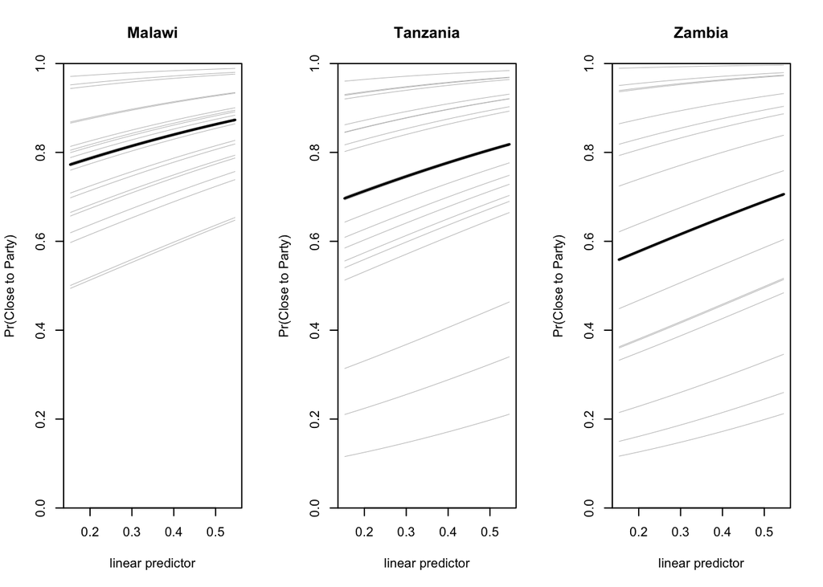

```r
library(lme4)
load("ranef_sd_se.RData")
## Form state-level RE mean predictions
pred_Z <- as.matrix(model.matrix(~AREA_scaled,
                       data = au)[,-1]) #Remove intercept
ranef_ab <- cbind(lme4::ranef(mod2)$COUNTRY, COUNTRY = rownames(lme4::ranef(mod2)$COUNTRY))
sub_ranef_ab <- merge(au, ranef_ab, all.x = TRUE)
sub_ranef_ab[is.na(sub_ranef_ab)] <- 0 #Replace unobserved states' intercept with mean (i.e. 0)
pred_country <- sub_ranef_ab["(Intercept)"]  +
  pred_Z %*% fixef(mod2)[c("AREA_scaled")] #this is now full estimated random intercept

## Form simulated random intercepts by taking draws from normal centered around
## estimated random intercept, using simulated SDs
re_sim <- laply(ranef_sd_se,
                function(x, mean_vec){
                  rnorm(length(mean_vec), mean_vec, x)
                },
                mean_vec = pred_country[[1]])

## Get range of data-level linear predictor
## (i.e. excluding state-level predictors)
linpred_range <- range(predict(mod2,
                               newdata = transform(model.frame(mod2)
                                                   , AREA_scaled = 0),
                               re.form=NA
))

##Create plots
par(mfrow=c(1,3))
for(country in c(countries_in_pred)){
  country_ind <- which(sub_ranef_ab$COUNTRY == country)
  plot (0, 0, xlim = linpred_range, ylim=c(0,1),
        yaxs="i", xlab="linear predictor", ylab="Pr(Close to Party)",
        main = sub_ranef_ab$COUNTRY[country_ind], type="n")
  for (sample in 1:20){
    curve(pnorm(re_sim[sample, country_ind] + x), lwd = .5, add = TRUE, col = "gray")
  }
  curve(pnorm(median(re_sim[, country_ind]) + x), lwd = 2, add = TRUE)
}
```

## Nested Random Effects

One of the advantages of `lme4` is that it allows us to estimate *nested random effects* models when we have data with multiple levels of dependence. We can extend the model above to allow the mean to the country random intercept to vary as a function of region.

$$\begin{align}
\text{party}_i &= \text{logit}^{-1}(\mathbf{x}_i\boldsymbol{\beta} + \alpha_{j[i]}) \\
\alpha &\sim \mathcal{N}(\mu, \sigma^2) \\
\mu_i &= \gamma\text{Region}_i \\
\end{align}$$

The way to do this in `glmer()` is `(1 | group1 / group2)` where `group2` is a smaller group nested in `group1` e.g. countries in regions, cities in states, armed groups in countries, etc. Estimate a model in `glmer()` that matches this new statistical mode.

```r
## fit model w/ nested random intercepts
mod3 <- glmer(Q90A ~ EA_FAC_A + EA_FAC_B + EA_FAC_C + EA_FAC_D + Q97 +
               (1 | REGION / COUNTRY), data = ab, family = binomial(link = 'logit'))

## present results
htmlreg(mod3, stars = .05, custom.coef.map = tab_map)
```

Statistical models

|  | Model 1 |
| --- | --- |
| Post Office | -0.13* |
|  | (0.03) |
| School | 0.11* |
|  | (0.04) |
| Police Station | -0.04 |
|  | (0.03) |
| Clinic | 0.03 |
|  | (0.03) |
| Education | -0.01* |
|  | (0.01) |
| AIC | 55186.72 |
| BIC | 55256.53 |
| Log Likelihood | -27585.36 |
| Num. obs. | 45581 |
| Num. groups: COUNTRY:REGION | 34 |
| Num. groups: REGION | 5 |
| Var: COUNTRY:REGION (Intercept) | 0.45 |
| Var: REGION (Intercept) | 0.12 |

*p < 0.05

While this nested approach allows us to account for more complex depdence structures, it also complicates the interpetation of our results. Now to get the intercept for a given country, we have to combine the fixed effect intercept, the country:region intercept, and the region intercept. Do this for South Africa, but remember that a `merMod` object is not an `lm` object, so we have to use the `beta` slot or `fixef()` to access the fixed effects.

```r
fixef(mod3)['(Intercept)'] + lme4::ranef(mod)[[1]][grepl('South Africa', rownames(lme4::ranef(mod3)[[1]])), ] +
  lme4::ranef(mod3)[[2]][grepl('Southern', rownames(lme4::ranef(mod3)[[2]])), ]
```

```
## (Intercept)
##         1.3
```

## Ordered Logits

While there are lots of different GLMs out in the world, `glmer()` can only really fit binomial and Poisson models. If you want to fit a multinomial probit, you’ll have to turn to another package. For today, we’re just going to look at ordered logistic regression via the `clmm()` function in the `ordinal` package. Cumulative link mixed models are another way of referring to random effects ordered logit (or probit) models. Just like `lme4`, `ordinal` supports nested random effects. Try fitting a model that explains a respondent’s level of trust in the president as a function of their economic condition, whether they’ve been a victim of property or violent crime, and their education level.

```r
library(ordinal)

## fit model
mod <- clmm(Q52A ~ Q4A + Q11A + Q11B + Q97 + (1 | REGION / COUNTRY), data = ab)
```

```
## Error in getY(fullmf): response needs to be a factor
```

```r
#doesn't work!
```

Unfortunately, `clmm()` isn’t quite as smart as `glmer()`. To make it happy, we need to make sure that our outcome variable, and any grouping variables, are factors. We don’t have to do this for `lmer()` because the function automatically checks that these variables are integers and converts them to factors if they are. Once we’ve taken care of that, we can fit the model.

```r
## convert outcome and country to factor
ab <- ab %>% mutate(Q52A = as.factor(Q52A),
                    COUNTRY = as.factor(COUNTRY),
                    REGION = as.factor(REGION))

## fit model
mod4 <- clmm(Q52A ~ Q4A + Q11A + Q11B + Q97 + (1 | REGION / COUNTRY), data = ab)

## present results
htmlreg(mod4, stars = .05, custom.coef.map = tab_map, groups = list('Predictors' = 1:4, 'Cutpoints' = 5:7))
```

Statistical models

|  | Model 1 |
| --- | --- |
| Predictors |  |
| Economic Condition | 0.45* |
|  | (0.01) |
| Property Crime | -0.06* |
|  | (0.01) |
| Violent Crime | -0.10* |
|  | (0.02) |
| Education | -0.09* |
|  | (0.00) |
| Cutpoints |  |
| 0\|1 | -0.76* |
|  | (0.10) |
| 1\|2 | 0.43* |
|  | (0.10) |
| 2\|3 | 1.50* |
|  | (0.10) |
| Log Likelihood | -56644.15 |
| AIC | 113306.30 |
| BIC | 113384.85 |
| Num. obs. | 45581 |
| Groups (COUNTRY:REGION) | 34 |
| Groups (REGION) | 5 |
| Variance: COUNTRY:REGION: (Intercept) | 0.32 |
| Variance: REGION: (Intercept) | 0.00 |

*p < 0.05

## Brief discussion of `lmer()` / `glmer()` syntax with regard to random slopes and intercepts

Here, I’m going to fit three different models, incorporating different ideas of random slopes - assuming that education here leads to some sort of varying effect that we need to capture. I want you to take a look at the summaries and particularly examine the section that Random Effects section - what is different among these models?

```r
modslope_1 <- glmer(Q90A ~ EA_FAC_A + EA_FAC_B + EA_FAC_C + EA_FAC_D +
                + (Q97 | COUNTRY),
              data = ab, family = binomial(link = 'logit'))

summary(modslope_1)
```

```
## Generalized linear mixed model fit by maximum likelihood (Laplace
##   Approximation) [glmerMod]
##  Family: binomial  ( logit )
## Formula: Q90A ~ EA_FAC_A + EA_FAC_B + EA_FAC_C + EA_FAC_D + +(Q97 | COUNTRY)
##    Data: ab
##
##      AIC      BIC   logLik deviance df.resid
##    54954    55024   -27469    54938    45573
##
## Scaled residuals:
##    Min     1Q Median     3Q    Max
## -2.461 -0.871  0.518  0.678  2.085
##
## Random effects:
##  Groups  Name        Variance Std.Dev. Corr
##  COUNTRY (Intercept) 0.89020  0.944
##          Q97         0.00828  0.091    -0.74
## Number of obs: 45581, groups:  COUNTRY, 34
##
## Fixed effects:
##             Estimate Std. Error z value Pr(>|z|)
## (Intercept)   0.3077     0.1186    2.59   0.0095 **
## EA_FAC_A     -0.1308     0.0327   -4.00  6.4e-05 ***
## EA_FAC_B      0.1146     0.0362    3.16   0.0016 **
## EA_FAC_C     -0.0281     0.0294   -0.96   0.3386
## EA_FAC_D      0.0164     0.0269    0.61   0.5418
## ---
## Signif. codes:  0 '***' 0.001 '**' 0.01 '*' 0.05 '.' 0.1 ' ' 1
##
## Correlation of Fixed Effects:
##          (Intr) EA_FAC_A EA_FAC_B EA_FAC_C
## EA_FAC_A -0.016
## EA_FAC_B -0.226 -0.023
## EA_FAC_C -0.009 -0.485   -0.061
## EA_FAC_D -0.043 -0.133   -0.260   -0.305
```

```r
modslope_2 <- glmer(Q90A ~ EA_FAC_A + EA_FAC_B + EA_FAC_C + EA_FAC_D +
                + (Q97 + 1 | COUNTRY),
              data = ab, family = binomial(link = 'logit'))

summary(modslope_2)
```

```
## Generalized linear mixed model fit by maximum likelihood (Laplace
##   Approximation) [glmerMod]
##  Family: binomial  ( logit )
## Formula: Q90A ~ EA_FAC_A + EA_FAC_B + EA_FAC_C + EA_FAC_D + +(Q97 + 1 |
##     COUNTRY)
##    Data: ab
##
##      AIC      BIC   logLik deviance df.resid
##    54954    55024   -27469    54938    45573
##
## Scaled residuals:
##    Min     1Q Median     3Q    Max
## -2.461 -0.871  0.518  0.678  2.085
##
## Random effects:
##  Groups  Name        Variance Std.Dev. Corr
##  COUNTRY (Intercept) 0.89020  0.944
##          Q97         0.00828  0.091    -0.74
## Number of obs: 45581, groups:  COUNTRY, 34
##
## Fixed effects:
##             Estimate Std. Error z value Pr(>|z|)
## (Intercept)   0.3077     0.1186    2.59   0.0095 **
## EA_FAC_A     -0.1308     0.0327   -4.00  6.4e-05 ***
## EA_FAC_B      0.1146     0.0362    3.16   0.0016 **
## EA_FAC_C     -0.0281     0.0294   -0.96   0.3386
## EA_FAC_D      0.0164     0.0269    0.61   0.5418
## ---
## Signif. codes:  0 '***' 0.001 '**' 0.01 '*' 0.05 '.' 0.1 ' ' 1
##
## Correlation of Fixed Effects:
##          (Intr) EA_FAC_A EA_FAC_B EA_FAC_C
## EA_FAC_A -0.016
## EA_FAC_B -0.226 -0.023
## EA_FAC_C -0.009 -0.485   -0.061
## EA_FAC_D -0.043 -0.133   -0.260   -0.305
```

```r
#what is different about this model here?
modslope_3 <- glmer(Q90A ~ EA_FAC_A + EA_FAC_B + EA_FAC_C + EA_FAC_D +
                + (Q97 - 1 | COUNTRY),
              data = ab, family = binomial(link = 'logit'))

summary(modslope_3)
```

```
## Generalized linear mixed model fit by maximum likelihood (Laplace
##   Approximation) [glmerMod]
##  Family: binomial  ( logit )
## Formula: Q90A ~ EA_FAC_A + EA_FAC_B + EA_FAC_C + EA_FAC_D + +(Q97 - 1 |
##     COUNTRY)
##    Data: ab
##
##      AIC      BIC   logLik deviance df.resid
##    56987    57039   -28488    56975    45575
##
## Scaled residuals:
##    Min     1Q Median     3Q    Max
## -2.989 -1.067  0.606  0.739  3.493
##
## Random effects:
##  Groups  Name Variance Std.Dev.
##  COUNTRY Q97  0.0204   0.143
## Number of obs: 45581, groups:  COUNTRY, 34
##
## Fixed effects:
##              Estimate Std. Error z value Pr(>|z|)
## (Intercept)  0.549953   0.033688   16.32  < 2e-16 ***
## EA_FAC_A    -0.247399   0.031416   -7.87  3.4e-15 ***
## EA_FAC_B     0.038338   0.034731    1.10     0.27
## EA_FAC_C    -0.000246   0.028554   -0.01     0.99
## EA_FAC_D    -0.013914   0.025912   -0.54     0.59
## ---
## Signif. codes:  0 '***' 0.001 '**' 0.01 '*' 0.05 '.' 0.1 ' ' 1
##
## Correlation of Fixed Effects:
##          (Intr) EA_FAC_A EA_FAC_B EA_FAC_C
## EA_FAC_A  0.034
## EA_FAC_B -0.762 -0.019
## EA_FAC_C  0.033 -0.493   -0.058
## EA_FAC_D -0.076 -0.134   -0.275   -0.306
```

For other syntax questions about `glmer()` and `lmer()`, I would also check out [this resource:](https://cran.r-project.org/web/packages/lme4/vignettes/lmer.pdf).

## Individual Exercise

Use the Global Terrorism Database contained in `GTD.csv` to estimate a model where the number of terrorist attacks in a country-year is explained by GDP per capita and VDEM’s polyarchy score (v2x_polyarchy). `WDI` and the `vdem` packages (https://github.com/xmarquez/vdem) are your friends. Include a random intercept term by country, and allow the mean of country random intercepts to vary by year. Produce a publication quality table of your results. Is there more variation between countries or between years?